# Omics: Functional Gene Annotation Analysis

Author

Seunghyeon Kang

Published

May 9, 2026

## Introduction

This analysis explores functional gene annotations across four bacterial strain types: Mal, Dimeth, Chlorp, and Diaz. Protein annotations were obtained from OmicsBox and are compared to identify shared and unique functional categories across strains.

## Setup

```r
# Load all required packages
library(tidyverse)
library(here)
```

```r
# Custom colorblind-friendly palette used throughout visualizations
colors_van_likes <- c(
  "#E69F00", # orange
  "#009E73", # bluish green
  "#F0E442", # yellow
  "#D55E00", # vermillion
  "#0072B2", # blue
  "#CC79A7"  # purple/pink
)
```

## Data Cleaning

```r
# Helper: read a list of OmicsBox .txt files and add strain metadata
read_omics_files <- function(files, strain_type) {
  files |>
    set_names() |>
    map_dfr(
      ~ read_tsv(.x, show_col_types = FALSE),
      .id = "file"
    ) |>
    mutate(
      Strain      = str_remove(file, "_omicsbox_table\\.txt$"),
      StrainType  = strain_type,
      Description = str_remove(Description, "^MULTISPECIES:\\s*")
    ) |>
    select(-file)
}
```

```r
# --- Mal / Dimeth strains (already combined in MalDimeth.csv) ---
mal_dimeth_df <- read_csv(
  here("MalDimeth.csv"),
  show_col_types = FALSE
) |>
  mutate(
    StrainType = case_when(
      str_detect(Strain, "^Dimeth") ~ "Dimeth",
      str_detect(Strain, "^Mal")   ~ "Mal",
      TRUE                          ~ "Other"
    ),
    Description = str_remove(Description, "^MULTISPECIES:\\s*")
  )

# --- Chlorp strains ---
chlorp_files <- c(
  "Chlorp2_omicsbox_table.txt",
  "Chlorp5_omicsbox_table.txt",
  "Chlorp7_omicsbox_table.txt",
  "Chlorp8_omicsbox_table.txt",
  "Chlorp10_omicsbox_table.txt",
  "Chlorp11_omicsbox_table.txt"
)

# --- Diaz strains ---
diaz_files <- c(
  "Diaz11_omicsbox_table.txt",
  "Diaz23_omicsbox_table.txt",
  "Diaz26_omicsbox_table.txt",
  "Diaz28_omicsbox_table.txt"
)

chlorp_df <- read_omics_files(chlorp_files, "Chlorp")
diaz_df   <- read_omics_files(diaz_files,   "Diaz")
```

```r
# Merge all strain data into one dataframe and save clean version
df <- bind_rows(mal_dimeth_df, chlorp_df, diaz_df)

write_csv(df, here("data_clean", "MalChlorpDimethDiaz.csv"))

# Helper: categorize gene annotations into broad functional groups
categorize_function <- function(desc) {
  desc <- str_to_lower(desc)
  case_when(
    str_detect(
      desc,
      "transporter|permease|abc|symporter|receptor|efflux"
    ) ~ "Transport",
    str_detect(
      desc,
      "regulator|transcription|sigma|response regulator|kinase|phosphatase|sensor"
    ) ~ "Regulation",
    str_detect(
      desc,
      "dehydrogenase|oxidoreductase|synthase|ligase|transferase|hydrolase|metabolic|biosynthetic|catabolic"
    ) ~ "Metabolism",
    str_detect(
      desc,
      "stress|resistance|glutathione|repair|tellurite|osm|detox"
    ) ~ "Stress/Defense",
    str_detect(
      desc,
      "ribosomal|elongation factor|polymerase|trna ligase"
    ) ~ "Information Processing",
    TRUE ~ "Other"
  )
}
```

## Visualizations

### Functional gene categories by strain

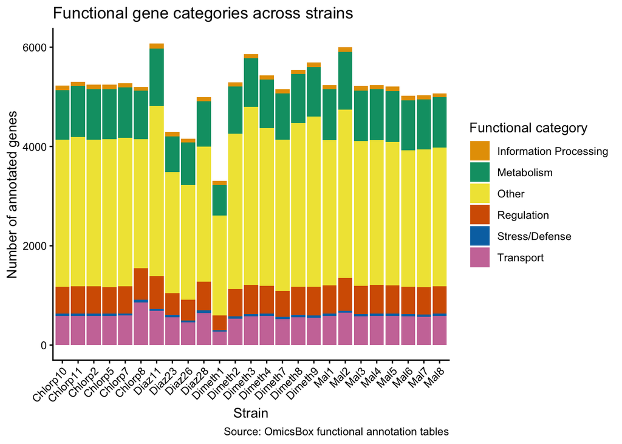

Figure 1: Stacked bar chart of annotated gene counts per strain, grouped by broad functional category.

```r
# Count genes per functional category within each strain
df |>
  mutate(Category = categorize_function(Description)) |>
  count(Strain, Category) |>
  ggplot(aes(x = Strain, y = n, fill = Category)) +
  geom_col() +
  scale_fill_manual(values = colors_van_likes) +
  labs(
    title   = "Functional gene categories across strains",
    x       = "Strain",
    y       = "Number of annotated genes",
    fill    = "Functional category",
    caption = "Source: OmicsBox functional annotation tables"
  ) +
  theme_classic() +
  theme(axis.text.x = element_text(angle = 45, hjust = 1))
```

Functional annotations were grouped into broad categories including metabolism, transport, regulation, stress/defense, and information processing. Transport- and metabolism-related genes were abundant across all Mal strains, with smaller differences among strains in stress/defense and regulatory genes.

### Gene sharing within strain types

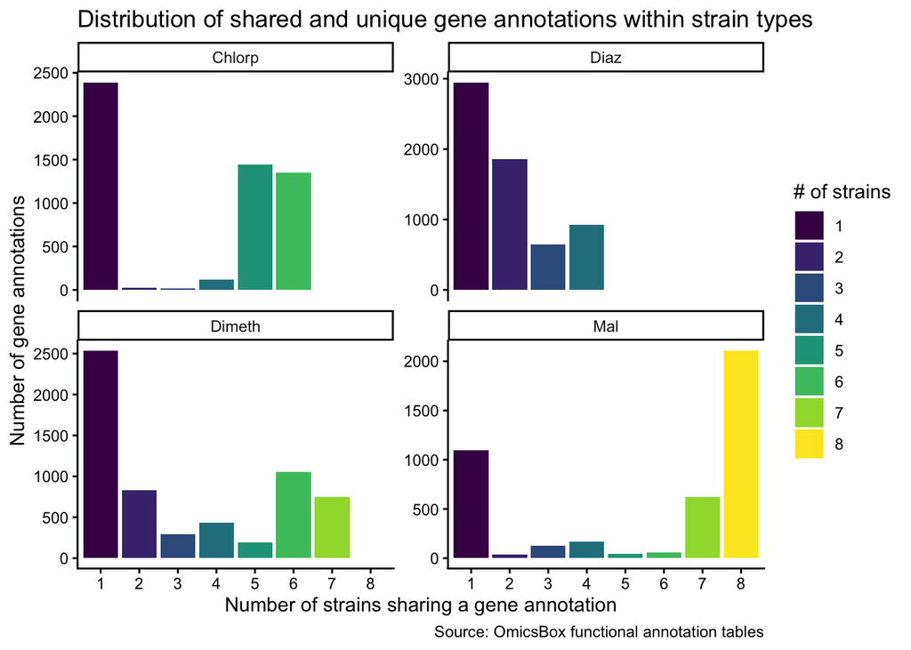

Figure 2: Distribution of how many strains within each strain type share a given gene annotation. High counts at x = 1 indicate many strain-specific genes; high counts at the maximum x value indicate a large shared core genome.

```r
# Count how many strains within a type share each annotation
shared_genes <- df |>
  filter(!is.na(Description), Description != "") |>
  distinct(StrainType, Strain, Description) |>
  count(StrainType, Description, name = "n_strains") |>
  count(StrainType, n_strains)

ggplot(shared_genes, aes(x = factor(n_strains), y = n, fill = factor(n_strains))) +
  geom_col() +
  scale_fill_viridis_d() +
  facet_wrap(~ StrainType, scales = "free_y") +
  labs(
    title   = "Distribution of shared and unique gene annotations within strain types",
    x       = "Number of strains sharing a gene annotation",
    y       = "Number of gene annotations",
    fill    = "# of strains",
    caption = "Source: OmicsBox functional annotation tables"
  ) +
  theme_classic()
```

The distribution of gene annotations shows a high number of genes shared across all strains and many genes unique to individual strains. Genes present in all strains likely represent core functions essential for survival, while strain-specific genes suggest functional diversity and adaptation to different environmental conditions.

Mal strains show a larger proportion of genes shared across all or most strains, indicating a more conserved core genome. In contrast, Dimeth strains have a higher proportion of genes unique to individual strains and fewer genes shared across all strains, suggesting greater genomic variability.

### Gene annotation sharing across strain types

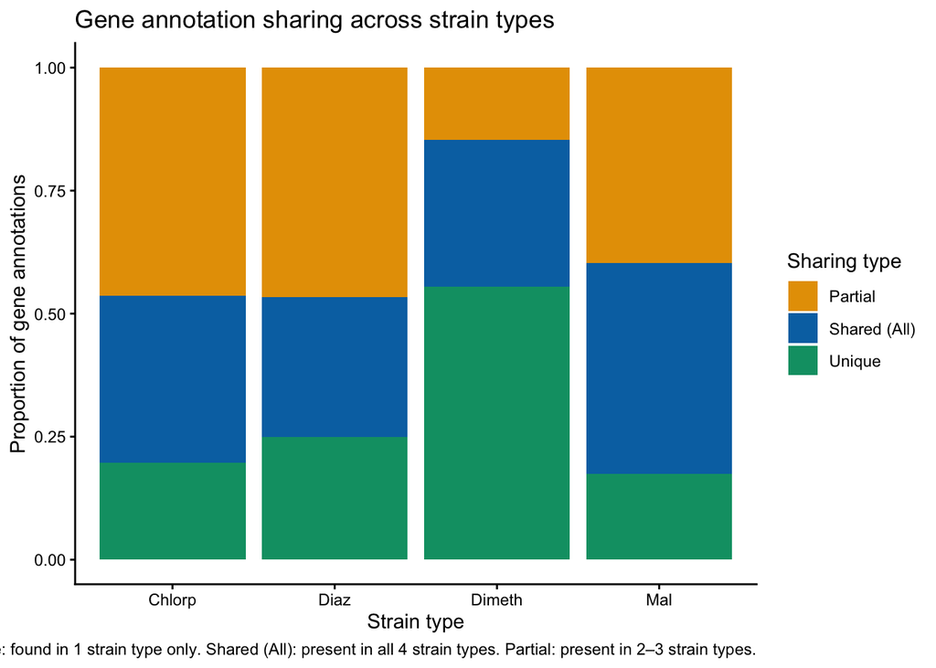

Figure 3: Proportional stacked bar chart showing what fraction of each strain type’s gene annotations are unique to that type, shared with all four types, or partially shared with 2–3 types.

```r
# Classify annotations as unique, partially shared, or shared across all types
n_types_total <- df |>
  distinct(StrainType) |>
  nrow()

df |>
  filter(!is.na(Description), Description != "") |>
  distinct(StrainType, Description) |>
  add_count(Description, name = "n_types") |>
  mutate(
    sharing_type = case_when(
      n_types == 1            ~ "Unique",
      n_types == n_types_total ~ "Shared (All)",
      TRUE                    ~ "Partial"
    )
  ) |>
  count(StrainType, sharing_type) |>
  ggplot(aes(x = StrainType, y = n, fill = sharing_type)) +
  geom_col(position = "fill") +
  scale_fill_manual(values = colors_van_likes[c(1, 5, 2)]) +
  labs(
    title   = "Gene annotation sharing across strain types",
    x       = "Strain type",
    y       = "Proportion of gene annotations",
    fill    = "Sharing type",
    caption = paste(
      "Unique: found in 1 strain type only.",
      "Shared (All): present in all 4 strain types.",
      "Partial: present in 2–3 strain types.",
      sep = " "
    )
  ) +
  theme_classic()
```

Gene annotations were compared based on functional descriptions, allowing identification of shared and unique functional categories across strain types.

### Functional composition by strain type

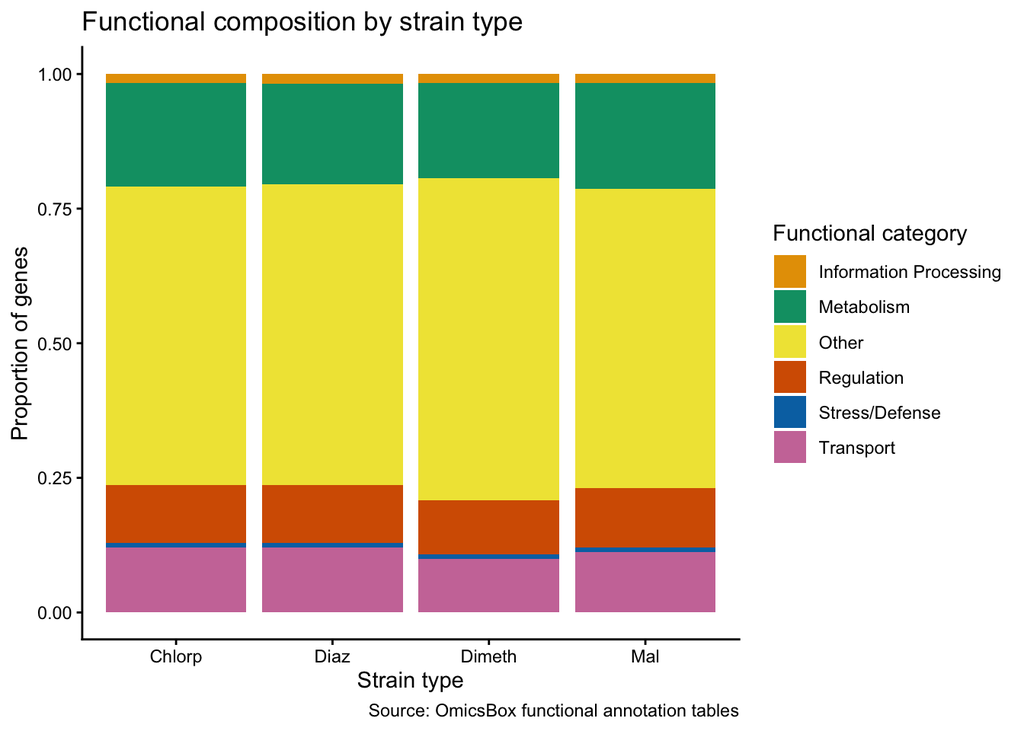

Figure 4: Proportional stacked bar chart of functional gene categories aggregated by strain type, allowing comparison of overall functional composition between Mal, Dimeth, Chlorp, and Diaz.

```r
# Summarise functional category proportions at the strain-type level
df |>
  mutate(Category = categorize_function(Description)) |>
  count(StrainType, Category) |>
  ggplot(aes(x = StrainType, y = n, fill = Category)) +
  geom_col(position = "fill") +
  scale_fill_manual(values = colors_van_likes) +
  labs(
    title   = "Functional composition by strain type",
    x       = "Strain type",
    y       = "Proportion of genes",
    fill    = "Functional category",
    caption = "Source: OmicsBox functional annotation tables"
  ) +
  theme_classic()
```